# Eligibility of Participant Type Variable

Julian Frattini

2024-06-21

This document compares the predictive power of the independent variables *participant type* with the more fine-grained *experience* and *domain knowledge* variables. Software engineering research often considers the type of a participant (either `student` or `practitioner`) a meaningful independent variable. However, it is reasonable to assume that this binary distinction is unnecessarily coarse and, conceptually, only a bad proxy for more meaningful variables[^1]. This investigation adds empirical evidence to our claim that the more fine-grained variables subsume the coarse participant type.

## Data Loading

```r
d.original <- load.data()
```

In addition to the already prepared data, load the participant type information and merge it to the main data.

```r
d.participant.type <- read.xlsx(file=file.path('../../data/raw', "rqi-participant-type.xlsx"), sheetName="type") %>%
  mutate(
    PID = as.numeric(PID),
    type = factor(type, levels=c('student', 'practitioner'), ordered=FALSE),
    )

d <- d.original %>%
  full_join(d.participant.type)
```

## Comparison

To empirically investigate our claim that our fine-grained variables subsume the participant type, we will compare three models with the different sets of factors regarding their predictive power using the leave-one-out (LOO) comparison.

### Formulae and Priors

We define three models with different sets of predictors (in addition to the common predictors like the treatment `RQ` or the experimental `period`):

1. `coarse`: only `participant.type`
2. `fine`: only fine-grained variables (`exp.se.scaled`, `exp.re.scaled`, `edu`, `primary.role`, `dom.os`, `dom.db`, `model.train`, `model.occ`)
3. `full`: both sets of predictors

Note that the `full` model is likely to be subject to multi-collinearity as, conceptually, the two sets of predictors encode the same information in different variables. Technically, the `full` model includes the same semantic information twice.

```r
f.coarse <- entities.missing | trials(entities.expected) ~ 1 +
  (1|PID) +
  RQ*period +
  duration.scaled +
  type
```

```r
f.fine <- entities.missing | trials(entities.expected) ~ 1 +
  (1|PID) +
  RQ*period +
  duration.scaled +
  exp.se.scaled + exp.re.scaled + edu + primary.role +
  dom.os + dom.db +
  model.train + model.occ
```

```r
f.full <- entities.missing | trials(entities.expected) ~ 1 +
  (1|PID) +
  RQ*period +
  duration.scaled +
  exp.se.scaled + exp.re.scaled + edu + primary.role +
  dom.os + dom.db +
  model.train + model.occ +
  type
```

We use uninformative priors which have already proven adequate in the `missing-entities.Rmd` investigation.

```r
priors <- c(
  prior(normal(-1, 0.2), class=Intercept),
  prior(normal(0, 0.1), class=b),
  prior(weibull(2, 1), class=sd)
)
```

### Model Training

Next, we train the three models with the given data and assumed priors.

```r
m.coarse <-
  brm(data = d, family = binomial, f.coarse, prior = priors,
    iter = 4000, warmup = 1000, chains = 4, cores = 4,
    seed = 4
  )
m.fine <-
  brm(data = d, family = binomial, f.fine, prior = priors,
    iter = 4000, warmup = 1000, chains = 4, cores = 4,
    seed = 4
  )
```

```
## recompiling to avoid crashing R session
```

```r
m.full <-
  brm(data = d, family = binomial, f.full, prior = priors,
    iter = 4000, warmup = 1000, chains = 4, cores = 4,
    seed = 4
  )
```

```
## recompiling to avoid crashing R session
```

To ensure that all models were trained correctly, we inspect posterior predictive checks.

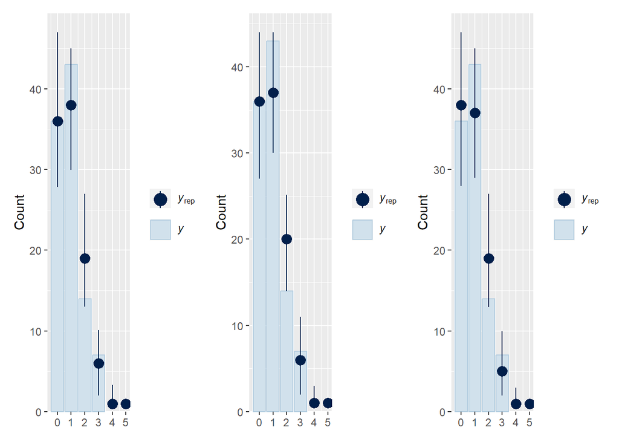

```r
ndraws <- 100

prior.pred.coarse <- brms::pp_check(m.coarse, type="bars", ndraws=ndraws)
prior.pred.fine <- brms::pp_check(m.fine, type="bars", ndraws=ndraws)
prior.pred.full <- brms::pp_check(m.full, type="bars", ndraws=ndraws)

prior.pred.coarse | prior.pred.fine | prior.pred.full
```

The posterior predictive checks confirm that the models have been trained appropriately.

### Comparison regarding predictive Power

We compare the predictive capability of the three models using the leave-one-out comparison.

```r
m.coarse <- add_criterion(m.coarse, criterion = "loo")
m.fine <- add_criterion(m.fine, criterion = "loo")
m.full <- add_criterion(m.full, criterion = "loo")

loo_compare(m.coarse, m.fine, m.full)
```

```
##          elpd_diff se_diff
## m.fine   0.0       0.0
## m.full   0.0       0.1
## m.coarse 0.0       0.3
```

The evaluation shows that all models perform fairly equal, though the `fine` model performs best. The `full` model should be viewed with caution given the risk of multi-collinearity. Overall, the results slightly favor the `fine` over the `coarse` approach.

[^1]: Salman, I., Misirli, A. T., & Juristo, N. (2015, May). Are students representatives of professionals in software engineering experiments?. In 2015 IEEE/ACM 37th IEEE international conference on software engineering (Vol. 1, pp. 666-676). IEEE.